# 05 ToothGrowth

Robert C Cline Sr

2022-04-16

#### **ToothGrowth** is a built-in dataset describing tooth growth in *Cavia porcellus* (South American guinea pigs) under different vitamin C treatments. `data()`

1. Are higher doses of vitamin C beneficial for tooth growth?
- see Figure 1.
2. Does the method of administration (orange juice, OJ, or ascorbic acid, VC) influence the effect of the dose?
- See Figures 2 and 3.
3. What would be the predicted tooth length of a guinea pig given 1 mg of vitamin C as ascorbic acid?
- To identify datasets which are loaded type: `data()`

data(ToothGrowth)

**Table 1**. Summary of ToothGrowth dataset.

OJ = Orange Juice; VC = ascorbic acid

|  | len | supp | dose |
| --- | --- | --- | --- |
|  | Min. : 4.20 | OJ:30 | Min. :0.500 |
|  | 1st Qu.:13.07 | VC:30 | 1st Qu.:0.500 |
|  | Median :19.25 | NA | Median :1.000 |
|  | Mean :18.81 | NA | Mean :1.167 |
|  | 3rd Qu.:25.27 | NA | 3rd Qu.:2.000 |
|  | Max. :33.90 | NA | Max. :2.000 |

**Table 2**. Sample OBS of ToothGrowth dataset.

OJ = Orange Juice; VC = ascorbic acid

| len | supp | dose |
| --- | --- | --- |
| 15.2 | OJ | 0.5 |
| 22.5 | VC | 1.0 |
| 25.5 | OJ | 2.0 |
| 17.3 | VC | 1.0 |
| 7.3 | VC | 0.5 |
| 23.3 | OJ | 1.0 |

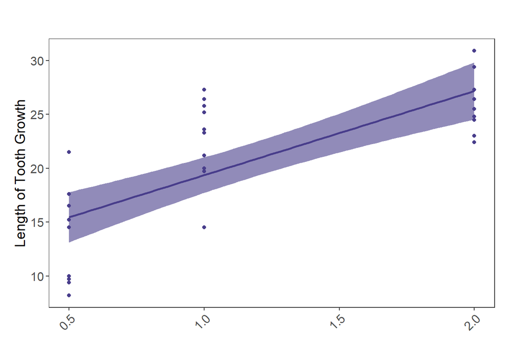

Figure 1. Tooth Growth as a function of Vitamin C dose

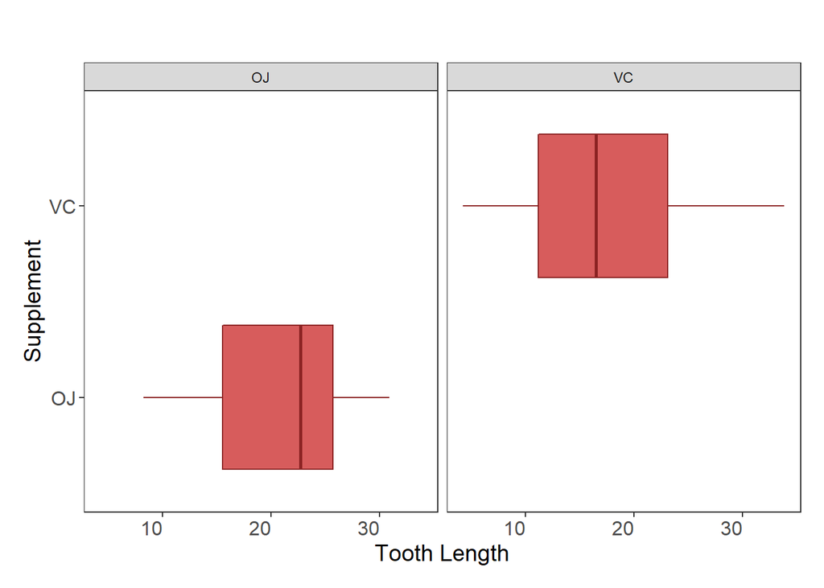

Figure 2. Tooth Length and Supplement Type

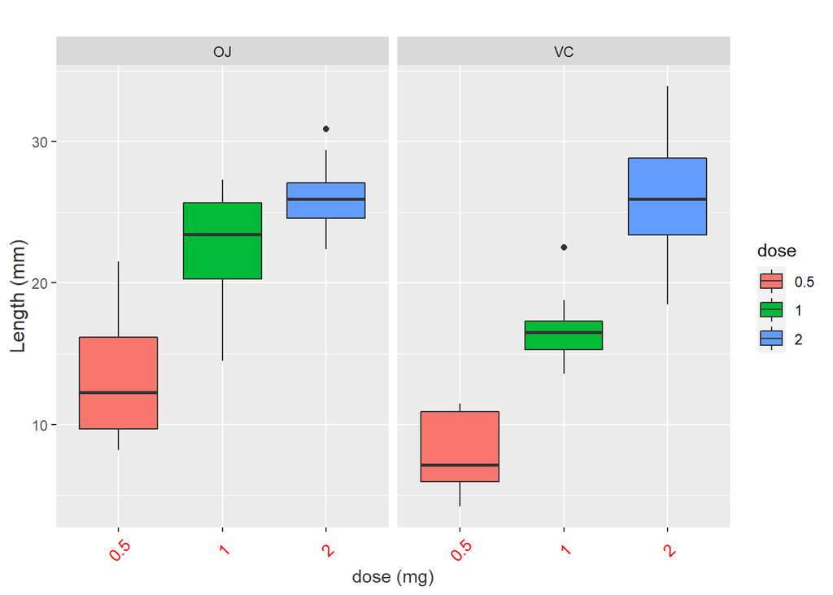

Figure 3. Tooth Growth Dependence on Dose and Supplement

What would be the predicted tooth length of a guinea pig given 1 mg of vitamin C as ascorbic acid?

**Table 3.** Regression Summary for tooth growth in guinea pigs with Vitamin C supplementation.

|  | len |  |  |
| --- | --- | --- | --- |
| Predictors | Estimates | CI | p |
| (Intercept) | 12.46 | 10.48 – 14.43 | **<0.001** |
| dose [1] | 9.13 | 6.71 – 11.55 | **<0.001** |
| dose [2] | 15.49 | 13.07 – 17.92 | **<0.001** |
| supp [VC] | -3.70 | -5.68 – -1.72 | **<0.001** |
| Observations | 60 |  |  |
| R<sup>2</sup> / R<sup>2</sup> adjusted | 0.762 / 0.750 |  |  |

```
##      fit      lwr      upr
## 1 21.585 13.66595 29.50405
```

[^1]: **Question**: Why does my calculation differ from the prediction calcuated from Table 3?